# (How feature can affect the trip duration)

## by (Samar Osailan)

## Investigation Overview

> To start with, this investigation will go through the process to look up how some features can affect the duration of a trip. The main features are: user type, bikes type, start station and end station

## Dataset Overview

> The dataset contains 158168 trips data for Bay Wheels's Ford GoBike described as rows with 13 features described as columns which are: 1- Bike ID 2- Bike type 3- Start Time and Date 4- End Time and Date 5- Start Station Name 6- Start Station ID 7- End Station Name 8- End Station ID 9- Start Station Latitude 10- Start Station Longitude 11- End Station Latitude 12- End Station Longitude 13- User Type (Subscriber or Customer – “Subscriber” = Member or “Customer” = Casual)

## Trip duration distribution

> The distirbution is right skewed where the number of trips started to increase from about 45000 to a peak of 50000 and then it starts to fall down under 10000 for more than 2000 seconds.

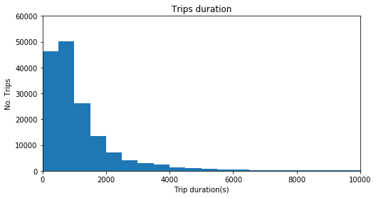

```python
binsize = 500
bins = np.arange(0, df['trip_duration'].max()+binsize, binsize)

plt.figure(figsize=[8, 4])
plt.hist(data = df, x = 'trip_duration', bins = bins)
plt.title('Trips duration')
plt.xlabel('Trip duration(s)')
plt.ylabel('No. Trips')
plt.axis([0, 10000, 0, 60000])
plt.show()
```

## User Type distribution

> The distirbution shows that casual users got a higher percentage

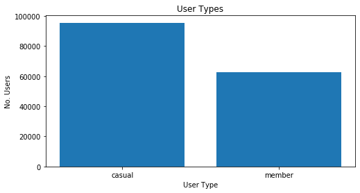

```python
plt.figure(figsize=[8, 4])
plt.bar(x = df.member_casual.value_counts().keys(), height = df.member_casual.value_counts() )
plt.title('User Types')
plt.xlabel('User Type')
plt.ylabel('No. Users')
plt.show()
```

## Bike Type distribution

> The distirbution shows that electric bikes got a higher percentage

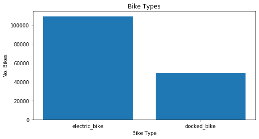

```python
plt.figure(figsize=[8, 4])
plt.bar(x = df.rideable_type.value_counts().keys(), height = df.rideable_type.value_counts() )
plt.title('Bike Types')
plt.xlabel('Bike Type')
plt.ylabel('No. Bikes')
plt.show()
```

## The relationship between the trip duration and the user type

> The distirbution shows that member users mostly got a shorter trip duration while casual users vary from short to long trips.

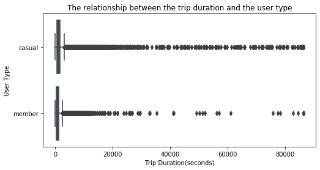

```python
plt.figure(figsize=[8,4])
base_color = sb.color_palette()[0]
sb.boxplot(data = df, x = 'trip_duration', y= 'member_casual', color = base_color)
plt.title('The relationship between the trip duration and the user type')
plt.xlabel('Trip Duration(seconds)')
plt.ylabel('User Type')
plt.show()
```

## The relationship between the trip duration and the bike type

> The distirbution shows that electric bike mostly got a shorter trip duration while docked bike vary from short to long trips.

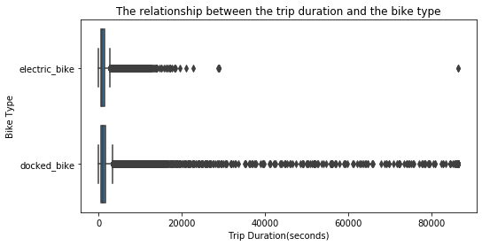

```python
plt.figure(figsize=[8,4])
base_color = sb.color_palette()[0]
sb.boxplot(data = df, x = 'trip_duration', y= 'rideable_type', color = base_color)
plt.title('The relationship between the trip duration and the bike type')
plt.xlabel('Trip Duration(seconds)')
plt.ylabel('Bike Type')
plt.show()
```

## The relationship between the trip duration, bike type and user type

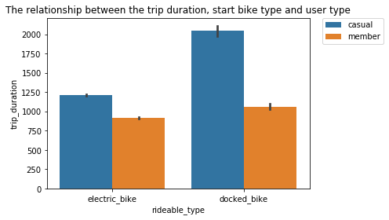

```python
sb.barplot(x='rideable_type',y='trip_duration',hue='member_casual',data=df)
plt.title('The relationship between the trip duration, start bike type and user type')
plt.legend(bbox_to_anchor=(1.05,1), loc=2, borderaxespad=0)
plt.show()
```